# Linear Regression Analysis

Pro-environmental Project

# Project Summary

## Overall

- Masses of people today are living lifestyles abundant in consumption, and this consumption drives greenhouse gas emissions, which ultimately drive the planet towards becoming a more inhospitable place to live (Hoekstra & Wiedmann, 2014; IPCC & Edenhofer, 2014; Ripple et al., 2020). This suggests a need for the development of effective climate-mitigation strategies that address widespread consumption habits.
- For this project, I developed and tested the effectiveness of two psychological intervention techniques aimed at improving people’s intentions to engage in a pro-environmental consumer behavior. For this study, the pro-environmental consumer outcome was intentions to reduce one’s clothing consumption in the future. The psychological intervention techniques included 1) a framing intervention, and 2) a norm intervention.

## Framing Intervention

- The framing intervention was used to frame the pro-environmental consumer behavior, reducing one’s clothing consumption, as helping the participant to pursue either 1) pro-environmental goals, or 2) self-interested goals.
- Participants were randomly assigned to one of three framing conditions, including:
  - **Control**: No framing information provided
  - **Pro-Environmental Framing**: Adoption of the pro-environmental behavior was described as helping the individual pursue pro-environmental goals
  - **Self-Enhancing Framing**: Adoption of the pro-environmental behavior was described as helping the individual pursue self-interested goals

## Norm Intervention

- Norm interventions work by altering people’s perception of the norms that are endorsed by the people around them. Norms are an effective intervention tool because people are prone toward adapting their behavior to match what they believe others in their group see as normal, effective, or desired ways of behaving.
- Directly following the framing intervention, participants were randomly assigned to read one of the five norm intervention conditions:
  - **Control**: No normative information provided)
  - **Convention**: Adopting this behavior helps to achieve common group goals
  - **Descriptive Norm**: Many people around you are adopting this behavior
  - **Social Norm**: Many people around you believe that people *should* adopt this behavior
  - **Moral Norm**: Many people around you believe that it is morally righteous to adopt this behavior

## Additional Measures

- In addition to the two key experimental interventions, participants were measured on several covariates that were controlled for in the model, including:
  - **Biospheric Values**: An appreciation for the natural environment and a desire to protect it
  - **Egoistic Values**: Concern with achieving greater resources for oneself
  - **Ingroup Identification**: Feeling like one belongs to the reference group, which, for this study, was other University of Oregon students
  - **Interest in Clothing**: General interest in and fascination with clothing

```r
library(rio) # for importing data
library(tidyverse) # for tidyverse tools
library(psych) # for descriptive statistics
library(readr) # for exporting csv files
library(naniar) # for visualizing missingness & MCAR test
library(sjPlot) # for summary output table
library(effectsize) # for effect size measures
library(lsr) # for etaSquared
library(broom) # for regression diagnostics
library(olsrr) # for outlier diagnostics
library(emmeans) # for estimated marginal means
library(papaja) # for APA tables
```

# Importing Data

## Import Data

```r
data <- import("proenv_clean_data.csv")
```

## Check Measure Types

```r
str(data, list.len = ncol(data))
```

## Transform Measure Types

```r
data <- data %>%
  mutate(ID = as.factor(id),
         consumer_behaviors = as.factor(consumer_behaviors),
         framing_condition = as.factor(framing_condition),
         norm_condition = as.factor(norm_condition),
         Gender = as.factor(Gender),
         Class_Lvl = as.factor(Class_Lvl),
         Employment = as.factor(Employment),
         Parents_Education = as.factor(Parents_Education),
         Pol_Ornt = factor(Pol_Ornt, labels = c("Very liberal", "Somewhat liberal", "Slightly liberal", "Neither liberal nor conservative", "Slightly conservative", "Somewhat conservative", "Very conservative", "Other")),
         Ethnicity = as.factor(Ethnicity))
```

## Subset Key Variables

```r
data <- data %>%
  dplyr::select(id, framing_condition, norm_condition, biospheric, egoistic, clothing_interest, ingroup_identification, consumer_intentions, consumer_behaviors, Age, Gender)
```

# Center Continuous Covariates

- Mean centering continuous variables prior to entering them in the model
  - Creates a meaningful y-intercept, and
  - Reduces multicollinearity if any continuous by continuous interaction effects are included.

## Biospheric Values

```r
data$biospheric_center <- data$biospheric - mean(data$biospheric, na.rm = TRUE)
```

## Egoistic Values

```r
data$egoistic_center <- data$egoistic - mean(data$egoistic, na.rm = TRUE)
```

## Ingroup Identification

```r
data$ingroup_identification_center <- data$ingroup_identification - mean(data$ingroup_identification, na.rm = TRUE)
```

## Interest in Clothing

```r
data$clothing_interest_center <- data$clothing_interest - mean(data$clothing_interest, na.rm = TRUE)
```

## Age

```r
data$Age_center <- data$Age - mean(data$Age, na.rm = TRUE)
```

# Contrast Coding Factors

- Contrast coding the factors included in the regression analysis.
  - Contrast codes ensures that factors are orthogonal, and
  - Produces easily interpretable regression coefficients

## Framing Condition

```r
FrameCode1 <- c(-1/2, 0, 1/2) # control vs self-enhancing
FrameCode2 <- c(-1/3, 2/3, -1/3) # arbitrary code

contrasts(data$framing_condition) <- cbind(FrameCode1, FrameCode2)
contrasts(data$framing_condition)
```

```
##                   FrameCode1 FrameCode2
## Control                 -0.5 -0.3333333
## Pro-Environmental        0.0  0.6666667
## Self-Enhancing           0.5 -0.3333333
```

## Norm Condition

```r
contrasts(data$norm_condition) <- contr.helmert(5)
contrasts(data$norm_condition) # control vs DN
```

```
##                  [,1] [,2] [,3] [,4]
## Control            -1   -1   -1   -1
## Convention          1   -1   -1   -1
## Descriptive Norm    0    2   -1   -1
## Moral Norm          0    0    3   -1
## Social Norm         0    0    0    4
```

## Gender

```r
contrasts(data$Gender) <- contr.helmert(5)
contrasts(data$Gender)
```

```
##                         [,1] [,2] [,3] [,4]
## Men                       -1   -1   -1   -1
## Non-binary                 1   -1   -1   -1
## Other                      0    2   -1   -1
## Prefers to not identify    0    0    3   -1
## Women                      0    0    0    4
```

# Fitting Model

```r
model <- lm(consumer_intentions ~ framing_condition*norm_condition + biospheric_center + egoistic_center + ingroup_identification_center + clothing_interest_center + Gender + Age_center, data = data)
```

# Checking Model Assumptions

## Linearity

- There does not appear to be a systematic pattern suggesting a non-captured non-linear trend.

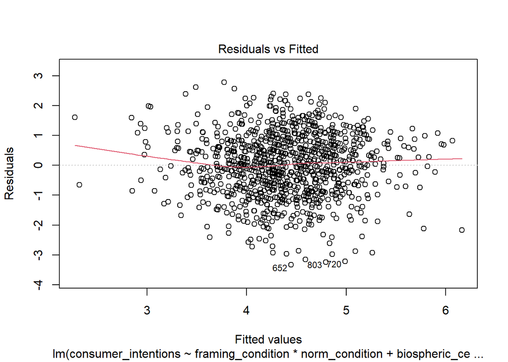

```r
plot(model, 1)
```

## Normally distributed residuals

- The distribution of residuals and QQ-plot indicate residuals are approximately normally distributed.

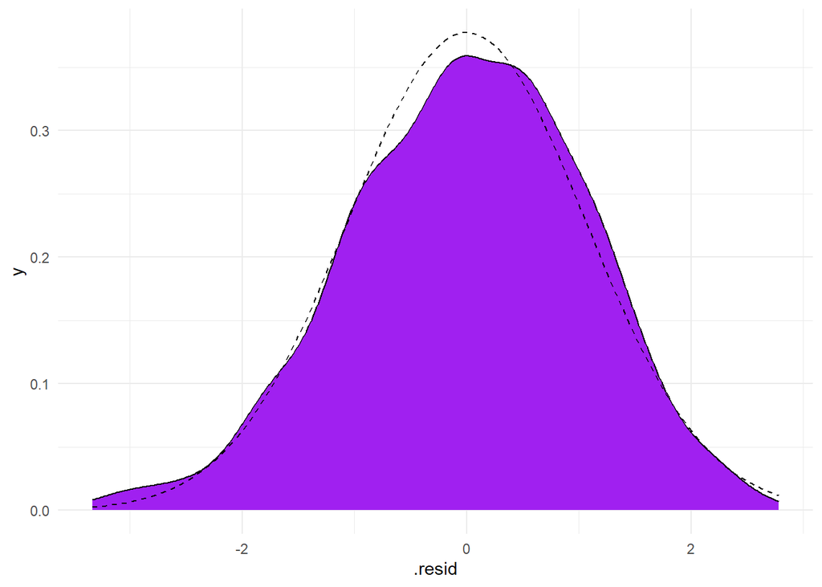

```r
# storing residuals
model_resids <- augment(model)

# plotting histogram of residuals
ggplot(data = model, aes(x = .resid)) +
  geom_density(fill = "purple") +
  stat_function(linetype = 2,
                fun      = dnorm,
                args     = list(mean = mean(model_resids$.resid),
                                sd   =   sd(model_resids$.resid))) +
  theme_minimal()
```

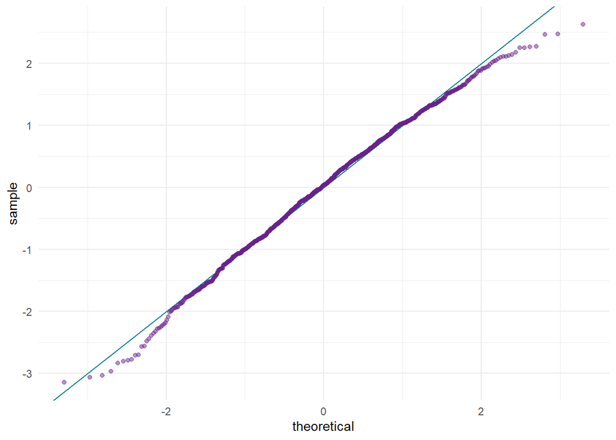

```r
# QQ-plot
ggplot(model) +
  geom_abline(color = "turquoise4") +
  stat_qq(aes(sample = .stdresid), color = "darkorchid4", alpha = .50) +
  theme_minimal()
```

## Homoscedasticity

- The residuals appear to be approximately equally distributed across the range of model values.

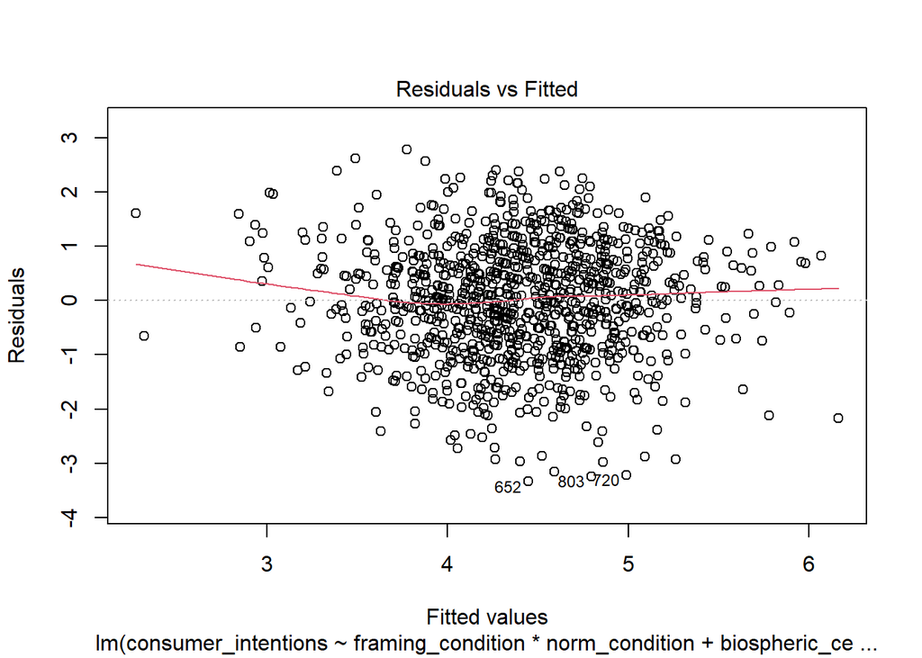

```r
plot(model, 1)
```

## Independent Residuals

- There does not appear to be any unexpected relationship between an arbitrary measure, like row number, and the model’s residuals.

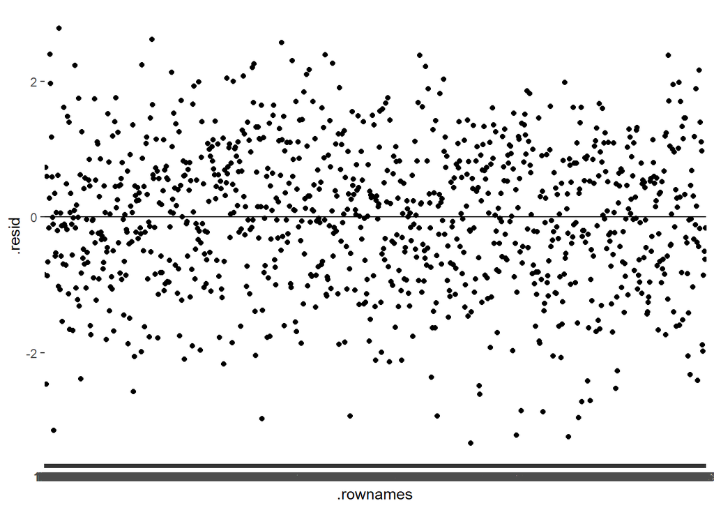

```r
# storing residuals
regr_diags <- augment(model)

# Plot residuals by row number
ggplot(data = regr_diags, aes(x = .rownames, y = .resid)) +
  geom_point() +
  geom_smooth(se = F) +
  geom_hline(yintercept = 0)
```

## Multivariate Outliers

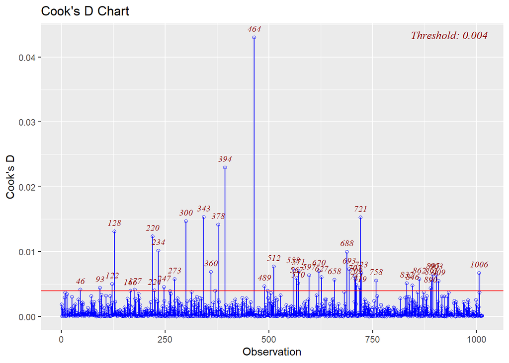

```r
# using olsrr function
ols_plot_cooksd_chart(model)
```

```r
# or grabbing from model augment output
cooks_d <- model_resids %>%
  dplyr::select(.rownames, .cooksd) %>%
  arrange(desc(abs(.cooksd)))

print(cooks_d, n = 10)
```

```
## # A tibble: 1,014 × 2
##    .rownames .cooksd
##    <chr>       <dbl>
##  1 541       0.0431
##  2 459       0.0230
##  3 394       0.0153
##  4 834       0.0153
##  5 344       0.0147
##  6 436       0.0142
##  7 143       0.0131
##  8 255       0.0124
##  9 272       0.0101
## 10 798       0.00997
## # ℹ 1,004 more rows
```

- Participant 541 is worth inspecting further as a potential multivariate outlier.

```r
potential_outlier <- model_resids %>%
  filter(.rownames == 541)
```

- Their values on all other measures are well within expected ranges so they will be kept in the analysis.

## Multicollinearity

```r
ols_vif_tol(model) %>%
  arrange(desc(abs(VIF)))
```

```
##                                      Variables Tolerance      VIF
## 1                                      Gender4 0.1767087 5.659031
## 2                                      Gender2 0.1781565 5.613044
## 3                                      Gender1 0.2963396 3.374507
## 4                                      Gender3 0.3575073 2.797146
## 5                     clothing_interest_center 0.8166185 1.224562
## 6                              egoistic_center 0.8590859 1.164028
## 7                                   Age_center 0.8882889 1.125760
## 8                            biospheric_center 0.8894393 1.124304
## 9                ingroup_identification_center 0.9275783 1.078076
## 10 framing_conditionFrameCode1:norm_condition4 0.9570435 1.044885
## 11                             norm_condition4 0.9717038 1.029120
## 12 framing_conditionFrameCode2:norm_condition3 0.9727925 1.027968
## 13 framing_conditionFrameCode1:norm_condition1 0.9763207 1.024254
## 14 framing_conditionFrameCode2:norm_condition4 0.9792532 1.021186
## 15                             norm_condition1 0.9818462 1.018489
## 16 framing_conditionFrameCode2:norm_condition1 0.9819178 1.018415
## 17                 framing_conditionFrameCode2 0.9823520 1.017965
## 18                             norm_condition3 0.9831494 1.017139
## 19                 framing_conditionFrameCode1 0.9853307 1.014888
## 20                             norm_condition2 0.9853833 1.014834
## 21 framing_conditionFrameCode1:norm_condition2 0.9916001 1.008471
## 22 framing_conditionFrameCode2:norm_condition2 0.9916908 1.008379
## 23 framing_conditionFrameCode1:norm_condition3 0.9920755 1.007988
```

# Overall Model Output

## ANOVA Table

```r
anova(model) %>%
  knitr::kable(digits = c(1, 2, 2, 2, 3), col.names = c("Predictor", "df", "SS", "MS", "F-statistic", "p-value"))
```

| Predictor | df | SS | MS | F-statistic | p-value |
| --- | --- | --- | --- | --- | --- |
| framing_condition | 2 | 4.47 | 2.24 | 1.96 | 0.142 |
| norm_condition | 4 | 8.21 | 2.05 | 1.80 | 0.128 |
| biospheric_center | 1 | 126.56 | 126.56 | 110.74 | 0.000 |
| egoistic_center | 1 | 119.67 | 119.67 | 104.71 | 0.000 |
| ingroup_identification_center | 1 | 3.76 | 3.76 | 3.29 | 0.070 |
| clothing_interest_center | 1 | 0.41 | 0.41 | 0.36 | 0.551 |
| Gender | 4 | 10.88 | 2.72 | 2.38 | 0.050 |
| Age_center | 1 | 9.40 | 9.40 | 8.23 | 0.004 |
| framing_condition:norm_condition | 8 | 4.67 | 0.58 | 0.51 | 0.849 |
| Residuals | 990 | 1131.45 | 1.14 | NA | NA |

## Summary Table

```r
tab_model(model, show.se = TRUE, show.fstat = TRUE)
```

|  | consumer intentions |  |  |  |
| --- | --- | --- | --- | --- |
| Predictors | Estimates | std. Error | CI | p |
| (Intercept) | 4.51 | 0.12 | 4.27 – 4.75 | **<0.001** |
| framing condition [FrameCode1] | 0.06 | 0.08 | -0.10 – 0.23 | 0.450 |
| framing condition [FrameCode2] | 0.16 | 0.07 | 0.02 – 0.30 | **0.029** |
| norm condition [1] | 0.05 | 0.05 | -0.06 – 0.15 | 0.397 |
| norm condition [2] | -0.01 | 0.03 | -0.07 – 0.05 | 0.704 |
| norm condition [3] | -0.03 | 0.02 | -0.08 – 0.01 | 0.144 |
| norm condition [4] | -0.03 | 0.02 | -0.06 – 0.00 | 0.066 |
| biospheric center | 0.37 | 0.04 | 0.30 – 0.44 | **<0.001** |
| egoistic center | -0.36 | 0.04 | -0.44 – -0.28 | **<0.001** |
| ingroup identification center | 0.04 | 0.03 | -0.03 – 0.11 | 0.251 |
| clothing interest center | -0.01 | 0.05 | -0.10 – 0.08 | 0.807 |
| Gender [1] | 0.21 | 0.12 | -0.02 – 0.44 | 0.078 |
| Gender [2] | 0.05 | 0.15 | -0.25 – 0.34 | 0.768 |
| Gender [3] | -0.03 | 0.09 | -0.21 – 0.16 | 0.780 |
| Gender [4] | -0.01 | 0.03 | -0.08 – 0.05 | 0.673 |
| Age center | -0.06 | 0.02 | -0.10 – -0.02 | **0.004** |
| framing condition [FrameCode1] × norm condition [1] | 0.03 | 0.13 | -0.23 – 0.28 | 0.845 |
| framing condition [FrameCode2] × norm condition [1] | -0.13 | 0.11 | -0.35 – 0.10 | 0.268 |
| framing condition [FrameCode1] × norm condition [2] | 0.11 | 0.08 | -0.04 – 0.26 | 0.155 |
| framing condition [FrameCode2] × norm condition [2] | -0.02 | 0.06 | -0.14 – 0.11 | 0.806 |
| framing condition [FrameCode1] × norm condition [3] | 0.03 | 0.05 | -0.08 – 0.14 | 0.581 |
| framing condition [FrameCode2] × norm condition [3] | -0.02 | 0.05 | -0.11 – 0.07 | 0.685 |
| framing condition [FrameCode1] × norm condition [4] | 0.02 | 0.04 | -0.06 – 0.10 | 0.623 |
| framing condition [FrameCode2] × norm condition [4] | 0.00 | 0.04 | -0.07 – 0.08 | 0.909 |
| Observations | 1014 |  |  |  |
| R<sup>2</sup> / R<sup>2</sup> adjusted | 0.203 / 0.184 |  |  |  |

## Effect Sizes

```r
etaSquared(model) %>%
  knitr::kable(digits = 3, col.names = c("Predictor", "Eta-Squared", "Partial Eta-Squared"))
```

| Predictor | Eta-Squared | Partial Eta-Squared |
| --- | --- | --- |
| framing_condition | 0.004 | 0.005 |
| norm_condition | 0.005 | 0.007 |
| biospheric_center | 0.087 | 0.098 |
| egoistic_center | 0.066 | 0.077 |
| ingroup_identification_center | 0.001 | 0.001 |
| clothing_interest_center | 0.000 | 0.000 |
| Gender | 0.005 | 0.006 |
| Age_center | 0.007 | 0.009 |
| framing_condition:norm_condition | 0.003 | 0.004 |

# Main Effect of Framing Condition

## Visualization

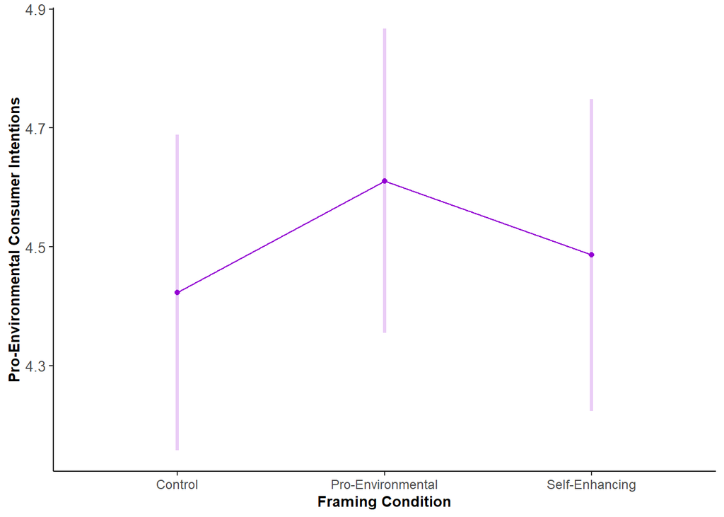

## Adjusted Means

```r
frame_means <- emmeans(model, pairwise ~ framing_condition, adjust = "none")

frame_means$emmeans %>%
  knitr::kable(digits = 2)
```

| framing_condition | emmean | SE | df | lower.CL | upper.CL |
| --- | --- | --- | --- | --- | --- |
| Control | 4.42 | 0.14 | 990 | 4.16 | 4.69 |
| Pro-Environmental | 4.61 | 0.13 | 990 | 4.35 | 4.87 |
| Self-Enhancing | 4.49 | 0.13 | 990 | 4.22 | 4.75 |

```r
frame_means$contrasts %>%
  knitr::kable(digits = c(NA,2,2,2,2,3))
```

| contrast | estimate | SE | df | t.ratio | p.value |
| --- | --- | --- | --- | --- | --- |
| Control - (Pro-Environmental) | -0.19 | 0.08 | 990 | -2.28 | 0.023 |
| Control - (Self-Enhancing) | -0.06 | 0.08 | 990 | -0.76 | 0.450 |
| (Pro-Environmental) - (Self-Enhancing) | 0.12 | 0.08 | 990 | 1.50 | 0.133 |

## Effect Sizes

```r
eff_size(frame_means, sigma = sigma(model), edf = df.residual(model)) %>%
  knitr::kable(digits = c(NA,2,2,2,2,3))
```

| contrast | effect.size | SE | df | lower.CL | upper.CL |
| --- | --- | --- | --- | --- | --- |
| (Control - (Pro-Environmental)) | -0.18 | 0.08 | 990 | -0.33 | -0.024 |
| (Control - (Self-Enhancing)) | -0.06 | 0.08 | 990 | -0.21 | 0.094 |
| ((Pro-Environmental) - (Self-Enhancing)) | 0.12 | 0.08 | 990 | -0.04 | 0.269 |

## Notes

- Pro-environmental consumer intentions were significantly higher in the pro-environmental framing condition (*M_{Adj}* = 4.61) compared to the control framing condition (*M_{Adj}* = 4.42), *t*(990) = -2.28, *p* = .023. This corresponded to a small effect size based on Cohen’s *d* conventions, *d* = 0.18.
- Pro-environmental consumer intentions were also descriptively higher in the pro-environmental framing condition compared to the self-enhancing framing condition (*M_{Adj}* = 4.49), but this difference was not significant, *t*(990) = 1.50, *p* = .133. However, this difference did correspond to a small effect size, *d* = 0.12.
- These findings suggest that framing a behavior as helping to achieve pro-environmental goals may persuade people to adopt it more than if no framing is used.

# Main Effect of Norm Condition

## Visualization

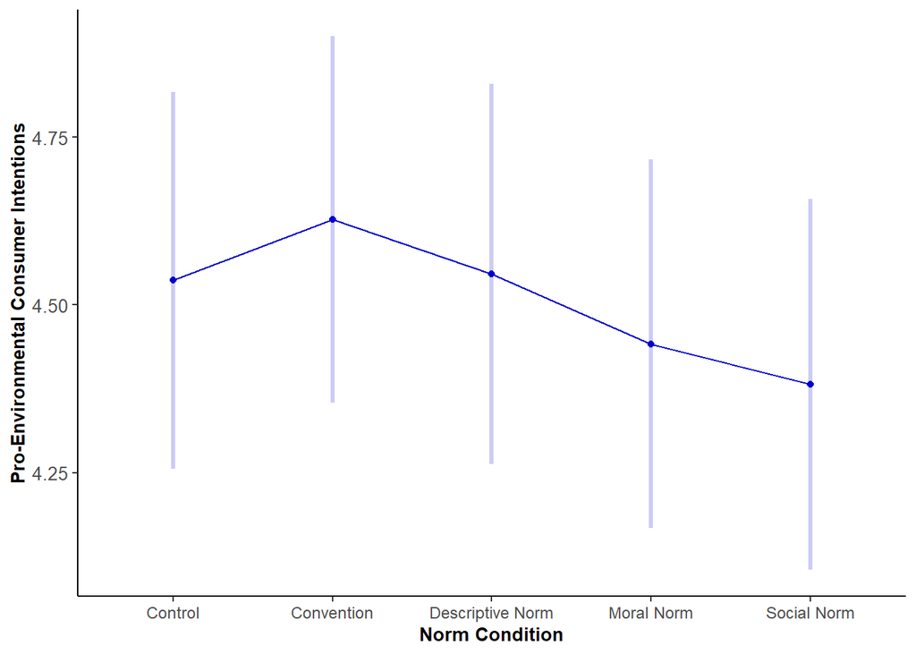

## Adjusted Means

```r
norm_means <- emmeans(model, pairwise ~ norm_condition, adjust = "none")

norm_means$emmeans %>%
  knitr::kable(digits = 2)
```

| norm_condition | emmean | SE | df | lower.CL | upper.CL |
| --- | --- | --- | --- | --- | --- |
| Control | 4.54 | 0.14 | 990 | 4.26 | 4.82 |
| Convention | 4.63 | 0.14 | 990 | 4.35 | 4.90 |
| Descriptive Norm | 4.55 | 0.14 | 990 | 4.26 | 4.83 |
| Moral Norm | 4.44 | 0.14 | 990 | 4.17 | 4.72 |
| Social Norm | 4.38 | 0.14 | 990 | 4.11 | 4.66 |

```r
norm_means$contrasts %>%
  knitr::kable(digits = 3)
```

| contrast | estimate | SE | df | t.ratio | p.value |
| --- | --- | --- | --- | --- | --- |
| Control - Convention | -0.090 | 0.107 | 990 | -0.847 | 0.397 |
| Control - Descriptive Norm | -0.010 | 0.106 | 990 | -0.093 | 0.926 |
| Control - Moral Norm | 0.095 | 0.106 | 990 | 0.892 | 0.372 |
| Control - Social Norm | 0.155 | 0.106 | 990 | 1.457 | 0.146 |
| Convention - Descriptive Norm | 0.081 | 0.108 | 990 | 0.746 | 0.456 |
| Convention - Moral Norm | 0.185 | 0.108 | 990 | 1.716 | 0.087 |
| Convention - Social Norm | 0.245 | 0.108 | 990 | 2.272 | 0.023 |
| Descriptive Norm - Moral Norm | 0.105 | 0.107 | 990 | 0.975 | 0.330 |
| Descriptive Norm - Social Norm | 0.165 | 0.108 | 990 | 1.532 | 0.126 |
| Moral Norm - Social Norm | 0.060 | 0.108 | 990 | 0.558 | 0.577 |

## Effect Sizes

```r
eff_size(norm_means, sigma = sigma(model), edf = df.residual(model)) %>%
  knitr::kable(digits = 2)
```

| contrast | effect.size | SE | df | lower.CL | upper.CL |
| --- | --- | --- | --- | --- | --- |
| (Control - Convention) | -0.08 | 0.1 | 990 | -0.28 | 0.11 |
| (Control - Descriptive Norm) | -0.01 | 0.1 | 990 | -0.20 | 0.19 |
| (Control - Moral Norm) | 0.09 | 0.1 | 990 | -0.11 | 0.28 |
| (Control - Social Norm) | 0.14 | 0.1 | 990 | -0.05 | 0.34 |
| (Convention - Descriptive Norm) | 0.08 | 0.1 | 990 | -0.12 | 0.27 |
| (Convention - Moral Norm) | 0.17 | 0.1 | 990 | -0.03 | 0.37 |
| (Convention - Social Norm) | 0.23 | 0.1 | 990 | 0.03 | 0.43 |
| (Descriptive Norm - Moral Norm) | 0.10 | 0.1 | 990 | -0.10 | 0.30 |
| (Descriptive Norm - Social Norm) | 0.15 | 0.1 | 990 | -0.04 | 0.35 |
| (Moral Norm - Social Norm) | 0.06 | 0.1 | 990 | -0.14 | 0.25 |

## Notes

- Although pro-environmental consumer intentions were highest when participants were shown a message describing a convention for adopting the behavior (*M_{Adj}* = 4.63), the difference from the control condition (*M_{Adj}* = 4.54) was non-significant, *t*(990) = -0.85, *p* = .397, and the effect size was small, *d* = 0.08.
- However, participants shown a convention for adopting a pro-environmental behavior did express significantly higher intentions to adopt it compared to participants shown a social norm (*M_{Adj}* = 4.38), *t*(990) = 2.27, *p* = .023. This difference corresponded to a small effect size, *d* = 0.23.
- There was no significant difference between any other two norm conditions, and all the remaining effect sizes were below *d* = 0.20.

# Framing by Norm Interaction Effect

## Visualization

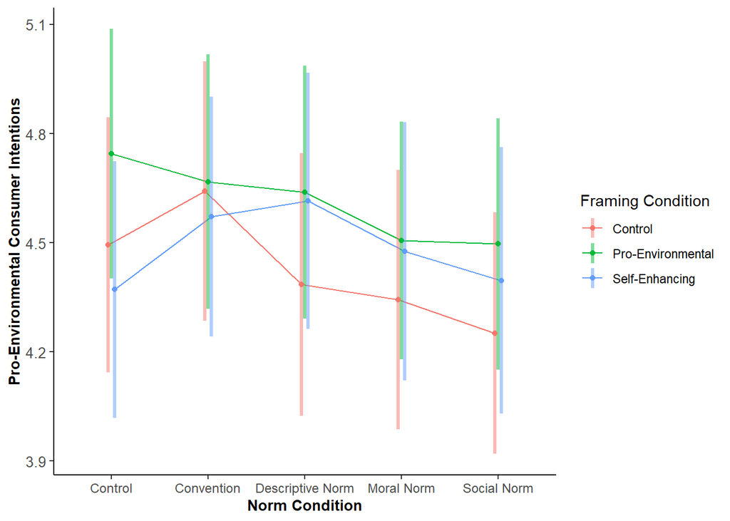

## Adjusted Means

```r
cell_means <- emmeans(model, pairwise ~ norm_condition | framing_condition, adjust = "none")

cell_means$emmeans %>%
  knitr::kable(digits = 2)
```

| norm_condition | framing_condition | emmean | SE | df | lower.CL | upper.CL |
| --- | --- | --- | --- | --- | --- | --- |
| Control | Control | 4.49 | 0.18 | 990 | 4.14 | 4.84 |
| Convention | Control | 4.64 | 0.18 | 990 | 4.29 | 5.00 |
| Descriptive Norm | Control | 4.39 | 0.18 | 990 | 4.02 | 4.75 |
| Moral Norm | Control | 4.34 | 0.18 | 990 | 3.99 | 4.70 |
| Social Norm | Control | 4.25 | 0.17 | 990 | 3.92 | 4.58 |
| Control | Pro-Environmental | 4.74 | 0.17 | 990 | 4.40 | 5.09 |
| Convention | Pro-Environmental | 4.67 | 0.18 | 990 | 4.32 | 5.02 |
| Descriptive Norm | Pro-Environmental | 4.64 | 0.18 | 990 | 4.29 | 4.99 |
| Moral Norm | Pro-Environmental | 4.51 | 0.17 | 990 | 4.18 | 4.83 |
| Social Norm | Pro-Environmental | 4.50 | 0.18 | 990 | 4.15 | 4.84 |
| Control | Self-Enhancing | 4.37 | 0.18 | 990 | 4.02 | 4.72 |
| Convention | Self-Enhancing | 4.57 | 0.17 | 990 | 4.24 | 4.90 |
| Descriptive Norm | Self-Enhancing | 4.62 | 0.18 | 990 | 4.26 | 4.97 |
| Moral Norm | Self-Enhancing | 4.48 | 0.18 | 990 | 4.12 | 4.83 |
| Social Norm | Self-Enhancing | 4.40 | 0.19 | 990 | 4.03 | 4.76 |

## Effect Sizes

```r
eff_size(cell_means, sigma = sigma(model), edf = df.residual(model)) %>%
  knitr::kable(digits = 2)
```

| contrast | framing_condition | effect.size | SE | df | lower.CL | upper.CL |
| --- | --- | --- | --- | --- | --- | --- |
| (Control - Convention) | Control | -0.14 | 0.18 | 990 | -0.48 | 0.21 |
| (Control - Descriptive Norm) | Control | 0.10 | 0.17 | 990 | -0.24 | 0.44 |
| (Control - Moral Norm) | Control | 0.14 | 0.17 | 990 | -0.20 | 0.48 |
| (Control - Social Norm) | Control | 0.23 | 0.16 | 990 | -0.09 | 0.54 |
| (Convention - Descriptive Norm) | Control | 0.24 | 0.18 | 990 | -0.12 | 0.60 |
| (Convention - Moral Norm) | Control | 0.28 | 0.18 | 990 | -0.08 | 0.64 |
| (Convention - Social Norm) | Control | 0.36 | 0.17 | 990 | 0.03 | 0.70 |
| (Descriptive Norm - Moral Norm) | Control | 0.04 | 0.18 | 990 | -0.31 | 0.39 |
| (Descriptive Norm - Social Norm) | Control | 0.12 | 0.17 | 990 | -0.21 | 0.46 |
| (Moral Norm - Social Norm) | Control | 0.09 | 0.17 | 990 | -0.24 | 0.41 |
| (Control - Convention) | Pro-Environmental | 0.07 | 0.17 | 990 | -0.26 | 0.41 |
| (Control - Descriptive Norm) | Pro-Environmental | 0.10 | 0.17 | 990 | -0.24 | 0.44 |
| (Control - Moral Norm) | Pro-Environmental | 0.22 | 0.17 | 990 | -0.11 | 0.56 |
| (Control - Social Norm) | Pro-Environmental | 0.23 | 0.18 | 990 | -0.11 | 0.58 |
| (Convention - Descriptive Norm) | Pro-Environmental | 0.03 | 0.17 | 990 | -0.30 | 0.36 |
| (Convention - Moral Norm) | Pro-Environmental | 0.15 | 0.17 | 990 | -0.18 | 0.48 |
| (Convention - Social Norm) | Pro-Environmental | 0.16 | 0.17 | 990 | -0.18 | 0.50 |
| (Descriptive Norm - Moral Norm) | Pro-Environmental | 0.12 | 0.17 | 990 | -0.21 | 0.46 |
| (Descriptive Norm - Social Norm) | Pro-Environmental | 0.13 | 0.17 | 990 | -0.21 | 0.48 |
| (Moral Norm - Social Norm) | Pro-Environmental | 0.01 | 0.17 | 990 | -0.33 | 0.35 |
| (Control - Convention) | Self-Enhancing | -0.19 | 0.17 | 990 | -0.52 | 0.15 |
| (Control - Descriptive Norm) | Self-Enhancing | -0.23 | 0.17 | 990 | -0.56 | 0.11 |
| (Control - Moral Norm) | Self-Enhancing | -0.10 | 0.17 | 990 | -0.44 | 0.25 |
| (Control - Social Norm) | Self-Enhancing | -0.02 | 0.18 | 990 | -0.38 | 0.33 |
| (Convention - Descriptive Norm) | Self-Enhancing | -0.04 | 0.17 | 990 | -0.38 | 0.29 |
| (Convention - Moral Norm) | Self-Enhancing | 0.09 | 0.18 | 990 | -0.25 | 0.43 |
| (Convention - Social Norm) | Self-Enhancing | 0.16 | 0.18 | 990 | -0.19 | 0.52 |
| (Descriptive Norm - Moral Norm) | Self-Enhancing | 0.13 | 0.17 | 990 | -0.21 | 0.47 |
| (Descriptive Norm - Social Norm) | Self-Enhancing | 0.20 | 0.18 | 990 | -0.15 | 0.56 |
| (Moral Norm - Social Norm) | Self-Enhancing | 0.07 | 0.18 | 990 | -0.29 | 0.44 |

## Notes

- As indicated by the non-significant norm by framing condition interaction effect in the overall model and the visualization of the interaction effect, the pattern of change in pro-environmental consumer intentions across the five norm conditions was similar for all three framing conditions.

# Main Effect of Biospheric Values

## Visualization

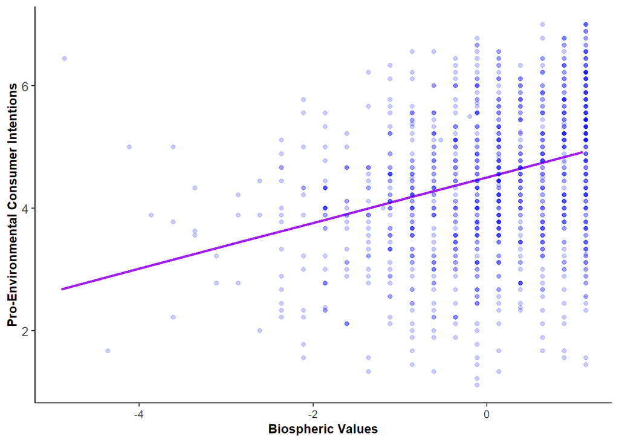

## Notes

- There was a significant, positive relationship between the degree to which participants endorsed biospheric values and their intentions to engage in pro-environmental consumer behaviors, *b* = 0.37, *p* < .001, 95%CI[0.30, 0.44]. Additionally, this relationship explained approximately 8.7% of the variation in participants’ pro-environmental consumer intentions.
- These findings suggest that, even when interventions are used in an attempt to improve people’s intentions to engage in pro-environmental consumer intentions, their already-existing endorsement of biopsheric values will still positively predict, over and above the effect of the intervention, their pro-environmental consumer intentions.

# Main Effect of Egoistic Values

## Visualization

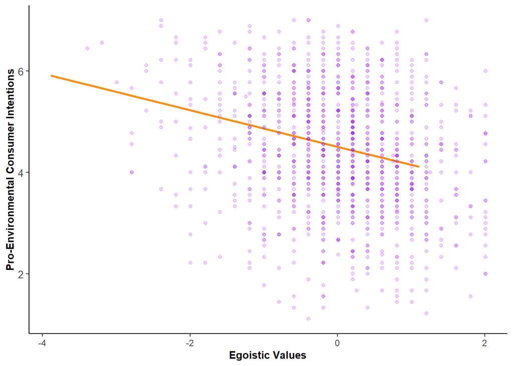

## Notes

- There was a significant, negative relationship between the degree to which participants endorsed egoistic values and their intentions to engage in pro-environmental consumer behaviors, *b* = -0.36, *p* < .001, 95%CI[-0.44, -0.28]. Additionally, this relationship explained approximately 6.6% of the variation in participants’ pro-environmental consumer intentions.
- These findings suggest that, even when interventions are used in an attempt to improve people’s intentions to engage in pro-environmental consumer intentions, their already-existing endorsement of egoistic values will still negatively predict, over and above the effect of the intervention, their pro-environmental consumer intentions.